[figure not shown]

# [Doctorado en Ingeniería (DocIng)](http://www.docing.ucm.cl/index.html)

# [Doctorado en Modelamiento Matemático Aplicado (DM<sub>2</sub>A)](http://vrip.ucm.cl/doctorado-en-modelamiento-matematico-aplicado/)

## Computación Científica II: Otras herramientas de visualización en Python

### Profesor: Dr. Ruber Hernández García

## Cambiando la visualización de datos... desde más Matplotlib, al infinito y más allá!

La visualización de datos es una parte cada vez más importante de la ciencia y el análisis de datos. En la clase anterior vimos como Matplotlib es la herramienta *de facto* para la visualización de datos en Python, pero esto no queda aquí, sino que podemos ir a un nivel superior.

Estamos viendo una tendencia de paquetes de Python que están trabajando para hacer que el análisis de Python sea más relevante para aquellos que están fuera del equipo de ciencia de datos. Una forma de hacerlo es a través de las visualizaciones. Las visualizaciones hacen que el análisis de datos sea comprensible para audiencias menos técnicas.

A continuación veremos otras librerías que nos permiten hacer visualizaciones más vistosas, de una manera fácil y accesible.

### Veamos un gráfico default generado por `matplotlib`:

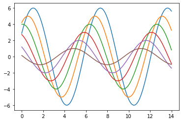

```python
import matplotlib.pyplot as plt
import numpy as np

def sinplot():
    x = np.linspace(0, 14, 100)
    for i in range(1, 7):
        plt.plot(x, np.sin(x + i * .5) * (7 - i))

sinplot()
```

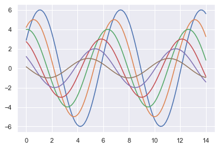

```python
import seaborn as sns   # magia !

#with sns.color_palette("Blues", desat=.7):
sinplot()
```

## Seaborn

[Seaborn](https://seaborn.pydata.org/) es una increíble biblioteca de visualización para el trazado de gráficos en Python. Proporciona hermosos estilos por defecto y paletas de colores para hacer que los gráficos sean más atractivos. Está construida sobre la biblioteca `matplotlib` y también está estrechamente integrada con las estructuras de datos de `pandas`.

Seaborn tiene como objetivo hacer que la visualización sea la parte central de la exploración y comprensión de los datos. Proporciona APIs orientadas al conjunto de datos, de modo que podemos cambiar entre diferentes representaciones visuales para las mismas variables para una mejor comprensión del conjunto de datos.

### Algunos ejemplos desde la [galería](https://seaborn.pydata.org/examples/index.html):

[figure not shown]

### Diferentes categorías de gráficos en Seaborn

Los gráficos se utilizan básicamente para visualizar la relación entre variables. Esas variables pueden ser completamente numéricas o una categoría como un grupo, clase o división. Seaborn divide los gráficos en las siguientes categorías:

- **Gráficos relacionales**: se utiliza para entender la relación entre dos variables.
- **Gráficos categóricos**: se ocupa para variables categóricas y de cómo se pueden visualizar.
- **Gráficos de distribución**: se utiliza para examinar las distribuciones univariantes y bivariantes.
- **Gráficos de regresión**: pensados principalmente para añadir una guía visual que ayude a enfatizar los patrones en un conjunto de datos durante los análisis exploratorios de datos.
- **Gráficos de matriz**: se utilizan para visualizar la dispersión de los datos.
- **Cuadrículas multigráficos**: útil para dibujar múltiples instancias del mismo gráfico en diferentes subconjuntos del conjunto de datos.

```python
# importing packages
import seaborn as sns

# loading dataset
data = sns.load_dataset("iris")

# draw lineplot
sns.lineplot(x="sepal_length", y="sepal_width", data=data)
```

```python
# Importing libraries
import numpy as np
import seaborn as sns


# Selecting style as white,
# dark, whitegrid, darkgrid
# or ticks
sns.set(style="darkgrid")

# Generate a random univariate
# dataset
rs = np.random.RandomState(10)
d = rs.normal(size=100)

# Plot a simple histogram and kde
# with binsize determined automatically
sns.histplot(d, kde=True, color="m")
```

```python
import seaborn as sns


sns.set(style="dark")
fmri = sns.load_dataset("fmri")

# Plot the responses for different\
# events and regions
sns.lineplot(x="timepoint",
             y="signal",
             hue="region",
             style="event",
             data=fmri)
```

```python
import seaborn as sns

sns.set(style="ticks")

# Loading the dataset
df = sns.load_dataset("anscombe")

# Show the results of a linear regression
sns.lmplot(x="x", y="y", data=df)
```

```python
# import the seaborn library
import seaborn as sns

# reading the dataset
df = sns.load_dataset('tips')

sns.boxplot(x='day', y='total_bill', data=df, hue='smoker')
```

```python
# import the seaborn library
import seaborn as sns

# reading the dataset
df = sns.load_dataset('tips')
sns.violinplot(x='day', y='total_bill', data=df,
               hue='smoker', split=True)
```

### Uso de Seaborn con Matplotlib

El uso conjunto de Matplotlib y Seaborn es un proceso muy sencillo. Sólo tenemos que invocar la función de trazado de Seaborn de forma normal, y luego podemos utilizar la función de personalización de Matplotlib.

```python
# importing packages
import seaborn as sns
import matplotlib.pyplot as plt

# loading dataset
data = sns.load_dataset("iris")

# draw lineplot
sns.lineplot(x="sepal_length", y="sepal_width", data=data)

# setting the title using Matplotlib
plt.title('Title using Matplotlib Function')

# setting the x limit of the plot
plt.xlim(5,7)

plt.show()
```

### Personalización de los gráficos con Seaborn

Seaborn viene con algunos temas personalizados y una interfaz de alto nivel para personalizar el aspecto de los gráficos. Considere el ejemplo anterior donde se utiliza el valor por defecto del Seaborn. Todavía se ve bien y bonito, pero podemos personalizar el gráfico de acuerdo a nuestras propias necesidades. Así que vamos a ver el estilo de los gráficos en detalle.

- Cambiando el estilo: `set_style()` se utiliza para establecer el estilo del gráfico. Esto significa que afecta a cosas como el color de los ejes, si la cuadrícula está activa o no, u otros elementos estéticos. Hay cinco temas disponibles en Seaborn: darkgrid, whitegrid, dark, white, ticks.
- Cambiar el tamaño de la figura: El tamaño de la figura se puede cambiar usando el método `figure()` de Matplotlib. El método crea una nueva figura del tamaño especificado que se pasa en el parámetro `figsize`.

```python
# importing packages
import seaborn as sns
import matplotlib.pyplot as plt

# loading dataset
data = sns.load_dataset("iris")

# changing the figure size
plt.figure(figsize = (10, 4))

# Selecting style as white,
# dark, whitegrid, darkgrid
# or ticks
sns.set(style="white")

# draw lineplot
sns.lineplot(x="sepal_length", y="sepal_width", data=data)

# Removing the spines
sns.despine()

plt.show()
```

- Escalado de los gráficos: Se puede hacer mediante el método `set_context()`. Anula los parámetros por defecto, afectando el tamaño de las etiquetas, líneas y otros elementos del gráfico, pero no al estilo general. El contexto base es "notebook", y los otros contextos son "paper", "talk", y "poster". `font_scale` establece el tamaño de la fuente.

```python
# importing packages
import seaborn as sns
import matplotlib.pyplot as plt

# loading dataset
data = sns.load_dataset("iris")

# draw lineplot
sns.lineplot(x="sepal_length", y="sepal_width", data=data)

# Setting the scale of the plot
sns.set_context("poster")

plt.show()
```

- Fijar el estilo temporalmente: el método `axes_style()` se utiliza para establecer el estilo temporalmente. Se utiliza junto con la sentencia `with`.

```python
# importing packages
import seaborn as sns
import matplotlib.pyplot as plt

# loading dataset
data = sns.load_dataset("iris")

# Setting the scale of the plot
sns.set_context("paper")

def plot():
    sns.lineplot(x="sepal_length", y="sepal_width", data=data)

with sns.axes_style('darkgrid'):
    # Adding the subplot
    plt.subplot(211)
    plot()

plt.subplot(212)
plot()
```

- Configuración de la paleta de colores por defecto: El método `set_palette()` se utiliza para establecer la paleta de colores por defecto para todos los gráficos. Los argumentos para `color_palette()` y `set_palette()` son los mismos. `set_palette()` cambia los parámetros por defecto de matplotlib.

```python
# importing packages
import seaborn as sns
import matplotlib.pyplot as plt

# loading dataset
data = sns.load_dataset("iris")

def plot():
	sns.lineplot(x="sepal_length", y="sepal_width", data=data)

# setting the default color palette
sns.set_palette('vlag')
plt.subplot(211)

# plotting with the color palette
# as vlag
plot()

# setting another default color palette
sns.set_palette('Accent')
plt.subplot(212)
plot()

plt.show()
```

- `pairplot()` representa la relación entre pares en todo el marco de datos y admite un argumento adicional llamado `hue` para la separación categórica. Lo que hace básicamente es crear un gráfico conjunto entre cada columna numérica posible y tarda un tiempo si el marco de datos es realmente enorme.

```python
# importing packages
import seaborn as sns
import matplotlib.pyplot as plt

# loading dataset
data = sns.load_dataset("iris")

sns.pairplot(data=data, hue='species')
plt.show()
```

- El mapa de calor se define como una representación gráfica de datos que utiliza colores para visualizar el valor de la matriz, se puede trazar utilizando la función `heatmap()`. En ella, para representar los valores más comunes o las actividades más altas se utilizan colores más brillantes, básicamente rojizos, y para representar los valores menos comunes o de actividad se prefieren los colores más oscuros.

```python
# importing packages
import seaborn as sns
import matplotlib.pyplot as plt

# loading dataset
data = sns.load_dataset("tips")

# correlation between the different parameters
tc = data.corr()

sns.heatmap(tc, annot=True)
plt.show()
```

## Mito

[Mito](https://www.trymito.io/) es un paquete gratuito de Python que permite a los usuarios llamar a una interfaz al estilo hoja de cálculo en su entorno Jupyter. Cada edición que realices en la hoja de cálculo generará el equivalente en Python en la celda de código inferior.

```
import mitosheet
mitosheet.sheet()
```

[figure not shown]

```python
from IPython.display import YouTubeVideo

YouTubeVideo('ip0PiZGSwV8', width=560)
```

### Mito: funcionalidades

Mito tiene un montón de grandes funcionalidades para el análisis exploratorio de datos, la limpieza de datos y el análisis de datos, incluyendo:

- Generación de gráficos y su código equivalente
- Creación de tablas dinámicas
- Fusión de conjuntos de datos
- Uso de fórmulas de hoja de cálculo
- Filtrar y ordenar conjuntos de datos
- Observación de las estadísticas de resumen
- Rellenar valores nulos
- y mucho más...

Aquí pueden consultar la [documentación completa](https://docs.trymito.io/getting-started/installing-mito).

## Plotly

[Plotly](https://plotly.com/graphing-libraries/) ofrece los gráficos estándar que todos los usuarios de Python querrían utilizar, de manera visualmente estimulantes o interactivos. Plotly está haciendo grandes progresos en estas dos áreas. Además dan acceso a gráficos avanzados, centrados en ML y AI.

[figure not shown]

La verdadera innovación es el enfoque de Plotly en los gráficos interactivos. En lugar de tener que preocuparse de ajustar el código cada vez que quiera cambiar la vista, Plotly le ofrece una interfaz gráfica para hacerlo.

Este es el primer ejemplo de la [documentación de Plotly](https://plotly.com/python/getting-started/).

En términos de una combinación de facilidad de configuración y flexibilidad del gráfico, Plotly es el mejor paquete de gráficos que he encontrado.

```python
import plotly.express as px

fig = px.bar(x=["a", "b", "c"], y=[1, 3, 2])
fig.show()
```

## Lux

[Lux](https://github.com/lux-org/lux) es una gran herramienta para la visualización y el análisis exploratorio de datos. Es posible tomar cualquier marco de datos y recomendará automáticamente visualizaciones que le ayuden a explorar y compartir los datos. No es necesario que escriba usted mismo ningún código de visualización.

```
import lux
import pandas as pd
```

A continuación, se puede ver cómo Lux proporciona opciones de visualización para cualquier marco de datos. Todo lo que tienes que hacer es seleccionar el gráfico que quieres, sin necesidad de codificar nada. Esto es un gran ahorro de tiempo, ya que conseguir la sintaxis correcta exacta de un paquete de como Matplotlib o Seaborn puede ser intensivo en tiempo.

[figure not shown]

```python
import lux
import pandas as pd

df = pd.read_csv("https://raw.githubusercontent.com/lux-org/lux-datasets/master/data/college.csv")
df
```

```python
df.intent = ["AverageCost","SATAverage"]
df
```

Lux también te permite exportar tus visualizaciones, lo que hace que el proceso de compartir sea fácil y sencillo. Puedes exportar las visualizaciones a HTML, o puedes convertirlas en el código equivalente de Matplotlib, para poder editarlas posteriormente.

Aquí pueden consultar la [documentación completa](https://lux-api.readthedocs.io/en/latest/index.html), donde además cuenta con una [galería de ejemplos](https://lux-api.readthedocs.io/en/latest/source/reference/gallery.html#).

```python
vis = df.exported[0]
print(vis.to_matplotlib())
vis
```